# The Association between Frailty and the Predictive Performance of ANZROD Score

Ryo Ueno, Ashwin Subramaniam

30/04/2020

For further details, please refer to this [online repository](https://github.com/ryo313/franzrod) or contact author

### Objectives of this report

- To clarify the motivation of the study
- To clarify the initial statistic plan
- To share the exploratory analysis results

### Summary of the key findings

- Both discrimination and calibration of ANZROD score differs amongst different frailty population
- This result may support the future research to incorporate frailty score into ANZROD.

Summary Table: Comparison of predictive values of ANZROD to predict in-hospital mortality in three cohorts

| frail_CFS | ROC | ROC_95CI | Brier_score | SMR | Hosmer_Lemeshow |
| --- | --- | --- | --- | --- | --- |
| non-frail | 0.928 | [ 0.916 ; 0.94 ] | 0.040 | 0.909 | 24.055 |
| pre-frail | 0.865 | [ 0.841 ; 0.888 ] | 0.072 | 0.981 | 29.904 |
| frail | 0.841 | [ 0.821 ; 0.861 ] | 0.104 | 1.053 | 26.275 |

### Background

- **Australian and New Zealand Risk of Death (ANZROD)** specific for Australian and New Zealand intensive care units (ICUs) has better calibration and discrimination in predicting mortality compared with the existing prognostic models such as APACHE III-j model.
- **Frailty** is a “physiological age” rather than a “chronological age”.
- Frailty is defined as a multidimensional syndrome characterised by a decline of physical, physiologic and cognitive reserves. Frailty increases with age and is characterised by a heterogeneous combination of decreased mobility, weakness, reduced muscle mass, poor nutritional status and diminished cognitive function.
- **ANZROD does not factor in frailty**, which is associated with worse prognosis in critically ill patients. Frailty is an independent risk factor after adjustment for classic risks such as severity, age, sex, comorbidities.
- We hypothesized that **ANZROD may underestimate the risk of mortality amongst frail populations**.

### Methods

#### Study design

- **Study design:** A multicentre retrospective cohort study
- **Setting:** 147 ICUs in Australia and New Zealand
- **Inclusion:** All ICU admissions from 2017 to 2018 in the ANZICS-APD
- **Exclusion:** Patietns without Clinical Frailty Scale data
- **prediction outcome:** in-hospital mortality
- **Frailty:** frailty was measured using [Clinical Frailty Scale (CFS)](https://github.com/ryo313/franzrod/blob/master/others/ClinicalFrailtyScale.png)

#### Statistic analysis

- All the patients were categorized in the following three groups  
  1. **non-frail (CFS = 1-3)**  
  2. **pre-frail (CFS = 4)**  
  3. **frail (CFS = 5-9)**
- In each cohort, we assessed the following predictive value of ANZROD to predict in-hospital mortality  
  1. **Area under the receiver operating characteristic curve (AUROC)**  
  2. **Brier score**  
  3. **Standardized Mortality Ratio (SMR)**  
  4. **Hosmer-Lemeshow goodness-of-fit**
- We created the receiver operating characteristic curve and calibration curve to.
- please refer to the [supplementary document](https://github.com/ryo313/franzrod/blob/master/citations/Paul2013_supplementary/1-s2.0-S0883944113002566-mmc3.doc) for the details of each values.

### Preliminary Analysis Results

#### Table 1-1: Patient characteristics: continuous variables

- Frail patients were older and have higher ANZROD score and APACHE-IIIj score.

Table 1-1: patient characteristics

| Variables | non.frail | pre.frail | frail |
| --- | --- | --- | --- |
| n | 5572 | 1955 | 1913 |
| Age (mean (SD)) | 57 (18) | 65 (15) | 69 (15) |
| ANZROD (median [IQR]) | 0.02 [0.01, 0.06] | 0.03 [0.01, 0.12] | 0.08 [0.03, 0.21] |
| APACHE 3 score (median [IQR]) | 43 [31, 59] | 54 [41, 69] | 58 [45, 74.] |
| APACHE 3 risk of death (median [IQR]) | 0.03 [0.01, 0.11] | 0.07 [0.02, 0.20] | 0.11 [0.05, 0.27] |

#### Table 1-2: Patient characteristics: categorical variables

- Frail cohort has more female patients.
- Frail cohort has more emergency ICU admissions.
- Frail cohort has more comoridities, especially chronic respiratory conditions.
- Frail cohort had higher mortality both during ICU and hospital stay.

Table 1-2: Patient characteristics

| variables | non.frail | pre.frail | frail |
| --- | --- | --- | --- |
| n | 5572 | 1955 | 1913 |
| Female (%) | 2160 ( 38.8) | 775 ( 39.6) | 899 ( 47.0) |
| Types of admission (%) |  |  |  |
| elective surgery | 1299 ( 23.3) | 482 ( 24.7) | 249 ( 13.0) |
| emergency surgery | 1104 ( 19.8) | 356 ( 18.2) | 391 ( 20.4) |
| medicine | 3169 ( 56.9) | 1117 ( 57.1) | 1273 ( 66.5) |
| Comorbidities (%) |  |  |  |
| respiratory | 215 ( 3.9) | 189 ( 9.7) | 368 ( 19.2) |
| cardiovascular | 236 ( 4.2) | 203 ( 10.4) | 271 ( 14.2) |
| liver disease | 111 ( 2.0) | 59 ( 3.0) | 80 ( 4.2) |
| renal disease | 128 ( 2.3) | 91 ( 4.7) | 153 ( 8.0) |
| immunocompromised | 59 ( 1.1) | 52 ( 2.7) | 82 ( 4.3) |
| immunomodulation treatment | 160 ( 2.9) | 184 ( 9.4) | 178 ( 9.3) |
| AIDS | 4 ( 0.1) | 1 ( 0.1) | 4 ( 0.2) |
| biopsy-proven liver failure | 21 ( 0.4) | 26 ( 1.3) | 25 ( 1.3) |
| lymphoma | 26 ( 0.5) | 31 ( 1.6) | 22 ( 1.2) |
| metastat ic cancer | 106 ( 1.9) | 69 ( 3.5) | 94 ( 4.9) |
| leukaemia | 53 ( 1.0) | 54 ( 2.8) | 44 ( 2.3) |
| ICU mortality (%) | 285 ( 5.1) | 138 ( 7.1) | 203 ( 10.6) |
| Hospital Mortality (%) | 375 ( 6.7) | 217 ( 11.1) | 325 ( 17.0) |

#### Table 2: Comparison of predictive values of ANZROD to predict in-hospital mortality in three cohorts

- ROC was lower amongst frail cohort compared with non-frail cohort
- Calibration values were similar amongst three categories.
- needs proofreading for the code

Table 2: Comparison of predictive values of ANZROD to predict in-hospital mortality in three cohorts

| frail_CFS | ROC | ROC_95CI | Brier_score | SMR | Hosmer_Lemeshow |
| --- | --- | --- | --- | --- | --- |
| non-frail | 0.928 | [ 0.916 ; 0.94 ] | 0.040 | 0.909 | 24.055 |
| pre-frail | 0.865 | [ 0.841 ; 0.888 ] | 0.072 | 0.981 | 29.904 |
| frail | 0.841 | [ 0.821 ; 0.861 ] | 0.104 | 1.053 | 26.275 |

#### Figure 1: Calibration Curve of ANZROD to predict inhospital mortality in three cohorts

- Diagonal line represents the line of perfect calibration.
- Graphically, calibration performance is worse amongst frail population.
- needs proofreading for the code

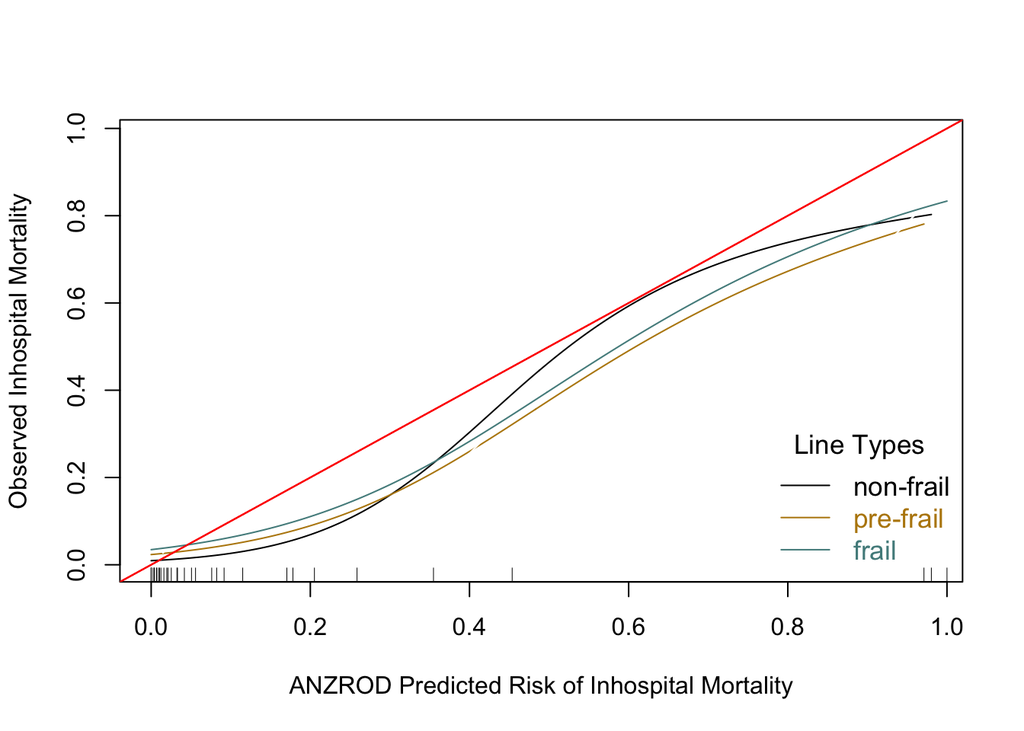

Figure 1:Calibration Curve of ANZROD to predict inhospital mortality in three cohorts

#### Figure 2: ROC of ANZROD to predict in-hospital mortality in three cohorts

- consistent with table 2, ROC shown that ANZROD performs worse in frail population compared with non-frial population.
- AUROC of ANROD to predict in-hospital mortality were as follows:  
  1. **non-frail:** 0.928 [ 0.916 ; 0.94 ]  
  2. **pre-frail:** 0.865 [ 0.841 ; 0.888 ]  
  3. **frail:** 0.841 [ 0.821 ; 0.861 ]

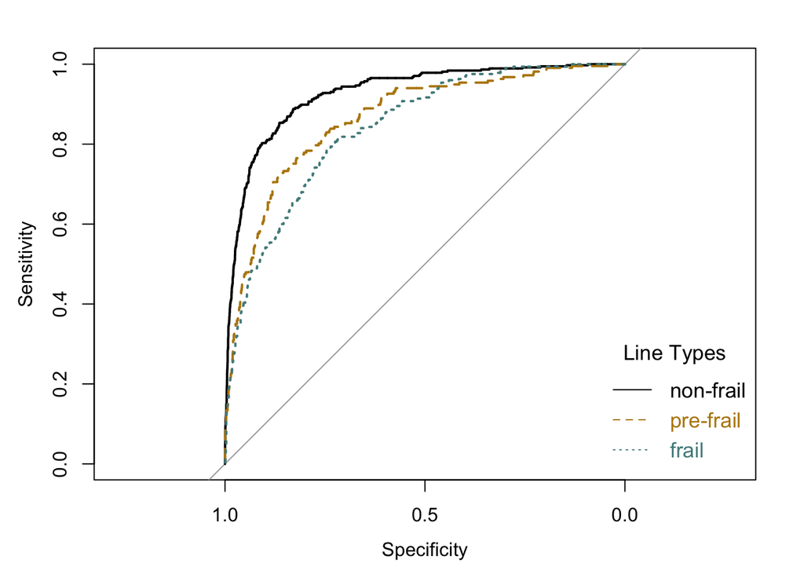

Figure 2: ROC of ANZROD to predict in-hospital mortality in three cohorts

### Limitations

- selection bias (patients without CFS were excluded); needs to count the number of hospitals in our dataset
- this study includes only 5% of the original cohort used for the development of ANZROD
- the clinical significance of the observed difference is unknown
- This result may just reflect the non-collapsibility of AUC; however, both clinical and epidemiological evidence supports the independent association of frailty with mortality

### Additional Analysis

#### Interaction between frailty and ANZROD

- An interaction between the two variables were confirmed by two different methods
- First, an interaction was measured in the following formula
- Additionally, an interaction was measured with CFS as a continuous variable.

```r
glm(I(died_hosp==1)~frail_CFS+anzrodriskofdeath+anzrodriskofdeath*frail_CFS, family=binomial,data=dt) %>% summary()
```

```
##
## Call:
## glm(formula = I(died_hosp == 1) ~ frail_CFS + anzrodriskofdeath +
##     anzrodriskofdeath * frail_CFS, family = binomial, data = dt)
##
## Deviance Residuals:
##     Min       1Q   Median       3Q      Max
## -2.6669  -0.3441  -0.2293  -0.2014   2.8057
##
## Coefficients:
##                                      Estimate Std. Error z value Pr(>|z|)
## (Intercept)                          -3.93252    0.09392 -41.872  < 2e-16
## frail_CFSpre-frail                    0.68805    0.15324   4.490 7.12e-06
## frail_CFSfrail                        1.08386    0.14314   7.572 3.68e-14
## anzrodriskofdeath                     7.94581    0.30090  26.406  < 2e-16
## frail_CFSpre-frail:anzrodriskofdeath -1.75509    0.47576  -3.689 0.000225
## frail_CFSfrail:anzrodriskofdeath     -2.17823    0.44621  -4.882 1.05e-06
##
## (Intercept)                          ***
## frail_CFSpre-frail                   ***
## frail_CFSfrail                       ***
## anzrodriskofdeath                    ***
## frail_CFSpre-frail:anzrodriskofdeath ***
## frail_CFSfrail:anzrodriskofdeath     ***
## ---
## Signif. codes:  0 '***' 0.001 '**' 0.01 '*' 0.05 '.' 0.1 ' ' 1
##
## (Dispersion parameter for binomial family taken to be 1)
##
##     Null deviance: 6016.2  on 9430  degrees of freedom
## Residual deviance: 4044.4  on 9425  degrees of freedom
##   (9 observations deleted due to missingness)
## AIC: 4056.4
##
## Number of Fisher Scoring iterations: 6
```

```r
glm(I(died_hosp==1)~frailty+anzrodriskofdeath+anzrodriskofdeath*frailty, family=binomial,data=dt) %>% summary()
```

```
##
## Call:
## glm(formula = I(died_hosp == 1) ~ frailty + anzrodriskofdeath +
##     anzrodriskofdeath * frailty, family = binomial, data = dt)
##
## Deviance Residuals:
##     Min       1Q   Median       3Q      Max
## -2.6134  -0.3263  -0.2409  -0.1918   2.9242
##
## Coefficients:
##                           Estimate Std. Error z value Pr(>|z|)
## (Intercept)               -4.73703    0.16449 -28.798  < 2e-16 ***
## frailty                    0.33884    0.03836   8.833  < 2e-16 ***
## anzrodriskofdeath          9.21316    0.50391  18.283  < 2e-16 ***
## frailty:anzrodriskofdeath -0.61860    0.11506  -5.376  7.6e-08 ***
## ---
## Signif. codes:  0 '***' 0.001 '**' 0.01 '*' 0.05 '.' 0.1 ' ' 1
##
## (Dispersion parameter for binomial family taken to be 1)
##
##     Null deviance: 6016.2  on 9430  degrees of freedom
## Residual deviance: 4027.6  on 9427  degrees of freedom
##   (9 observations deleted due to missingness)
## AIC: 4035.6
##
## Number of Fisher Scoring iterations: 6
```

#### repeat analysis with dichotomized frailty data

Table 2: Comparison of predictive values of ANZROD to predict in-hospital mortality in two cohorts

| frail_CFS_di | ROC | ROC_95CI | Brier_score | SMR | Hosmer_Lemeshow |
| --- | --- | --- | --- | --- | --- |
| non-frail | 0.911 | [ 0.9 ; 0.922 ] | 0.048 | 0.934 | 28.414 |
| frail | 0.841 | [ 0.821 ; 0.861 ] | 0.104 | 1.053 | 26.275 |

- For further details, please refer to this [online repository](https://github.com/ryo313/franzrod) or contact author